# DIF Exercises: Group 2 — Solutions

Derek Briggs

2026-04-19

# 1 Overview

In this assignment you will apply the DIF detection methods covered in class to a **simulated** dataset. The data contain 2,000 examinees (1,000 per gender group), 28 dichotomous items, and a gender indicator variable (`Male`: 0 = Female, 1 = Male). Some of the items were simulated to contain DIF. Your task is to find them using both the Mantel-Haenszel approach and the `lordif` approach, and to compare the results.

# 2 The Ground Truth

Because this is simulated data, we know exactly which items contain DIF and the nature of that DIF. This section reveals the generating parameters so we can evaluate how well each detection method performs.

**Impact (group ability differences):**

- Female $\theta \sim N(1.15, 1.0)$
- Male $\theta \sim N(1.00, 1.1)$
- Females have slightly higher mean ability; males have slightly more variability

**DIF items:** 8 of 28 items contain DIF. The DIF is **predominantly in one direction** — 7 items favor females and only 1 favors males:

```r
library(kableExtra)

truth <- data.frame(
  Item = c(5, 10, 15, 20, 25, 26, 27, 28),
  Direction = c("Favors Females", "Favors Females", "Favors Females",
                "Favors Females", "Favors Females", "Favors Females",
                "Favors Females", "Favors Males"),
  b_shift = c("1.2 logits harder for males",
              "1.1 logits harder for males",
              "1.0 logits harder for males (+ non-uniform)",
              "0.9 logits harder for males",
              "0.8 logits harder for males",
              "0.7 logits harder for males",
              "0.6 logits harder for males",
              "1.0 logits harder for females"),
  DIF_Type = c("Uniform", "Uniform", "Non-uniform",
               "Uniform", "Uniform", "Uniform",
               "Uniform", "Uniform"),
  Notes = c("", "",
            "Male discrimination is 0.9 higher than female",
            "", "", "", "", "Only item favoring males")
)

truth |>
  kable("html",
        col.names = c("Item", "Direction", "Difficulty Shift",
                       "DIF Type", "Notes")) |>
  kable_styling(full_width = FALSE)
```

| Item | Direction | Difficulty Shift | DIF Type | Notes |
| --- | --- | --- | --- | --- |
| 5 | Favors Females | 1.2 logits harder for males | Uniform |  |
| 10 | Favors Females | 1.1 logits harder for males | Uniform |  |
| 15 | Favors Females | 1.0 logits harder for males (+ non-uniform) | Non-uniform | Male discrimination is 0.9 higher than female |
| 20 | Favors Females | 0.9 logits harder for males | Uniform |  |
| 25 | Favors Females | 0.8 logits harder for males | Uniform |  |
| 26 | Favors Females | 0.7 logits harder for males | Uniform |  |
| 27 | Favors Females | 0.6 logits harder for males | Uniform |  |
| 28 | Favors Males | 1.0 logits harder for females | Uniform | Only item favoring males |

Key features of this dataset:

- The DIF is overwhelmingly **one-directional** (7 of 8 items favor females), so we would expect DIF to **amplify** at the test level rather than cancel
- Item 15 is the only item with **non-uniform DIF** (the male discrimination is 0.9 logits higher than the female) — this creates crossing ICCs that MH may struggle to detect
- The DIF magnitudes range from moderate (0.6 logits) to large (1.2 logits)
- Item 28 is the sole item favoring males, going against the prevailing direction
- The remaining 20 items have identical parameters for males and females

With this ground truth in mind, let’s see what the MH and `lordif` methods recover.

# 3 Exercise 1: Load and Explore the Data

Load the dataset `DIF.data2.csv`. Examine the structure of the data using `head()`, `tail()`, `nrow()`, and `ncol()`. Convert the `Male` variable to a factor with labels “Female” and “Male”.

```r
# Load the data
DIF.data <- read.csv("DIF.data2.csv")

# Convert Male to a factor
DIF.data$Male <- factor(DIF.data$Male, levels = c(0, 1),
                        labels = c("Female", "Male"))

# Explore the data
head(DIF.data)
```

```
##   V1 V2 V3 V4 V5 V6 V7 V8 V9 V10 V11 V12 V13 V14 V15 V16 V17 V18 V19 V20 V21
## 1  1  1  1  1  1  1  1  1  1   1   1   1   1   1   1   1   1   1   1   1   1
## 2  1  1  1  1  0  1  1  1  1   1   1   0   1   0   1   1   0   1   1   1   1
## 3  1  0  1  1  0  1  1  1  1   1   1   1   1   0   1   1   1   1   1   1   1
## 4  0  1  1  1  1  1  0  1  1   1   1   1   1   0   1   1   1   1   1   1   1
## 5  1  0  1  1  0  0  1  1  1   1   1   1   1   0   1   1   1   1   1   1   0
## 6  1  1  1  1  0  0  1  1  0   1   1   0   1   1   1   0   1   1   1   1   1
##   V22 V23 V24 V25 V26 V27 V28   Male
## 1   1   1   0   1   1   1   1 Female
## 2   0   1   1   1   1   1   1 Female
## 3   1   1   1   1   1   1   0 Female
## 4   1   1   1   1   1   1   1 Female
## 5   1   0   1   1   1   1   0 Female
## 6   0   1   1   0   1   1   1 Female
```

```r
tail(DIF.data)
```

```
##      V1 V2 V3 V4 V5 V6 V7 V8 V9 V10 V11 V12 V13 V14 V15 V16 V17 V18 V19 V20 V21
## 1995  1  1  1  0  1  1  1  0  1   0   1   1   1   1   0   1   1   0   1   0   1
## 1996  0  1  1  0  1  1  0  1  1   1   1   1   0   1   1   1   0   0   1   0   1
## 1997  1  1  1  1  0  1  0  1  1   0   1   0   1   1   1   1   1   1   0   1   1
## 1998  0  1  0  0  0  0  1  0  1   0   0   0   0   1   0   1   1   0   1   0   0
## 1999  0  1  0  1  0  1  0  0  1   1   0   0   1   0   0   1   1   0   0   0   0
## 2000  1  1  1  0  1  1  1  1  1   1   1   1   1   1   1   1   1   1   1   1   1
##      V22 V23 V24 V25 V26 V27 V28 Male
## 1995   1   0   1   0   1   1   0 Male
## 1996   1   1   1   0   1   1   0 Male
## 1997   1   1   0   0   1   0   1 Male
## 1998   1   1   1   1   1   0   1 Male
## 1999   1   0   0   1   0   0   0 Male
## 2000   1   1   1   1   0   1   1 Male
```

```r
nrow(DIF.data)
```

```
## [1] 2000
```

```r
ncol(DIF.data)
```

```
## [1] 29
```

**Question 1a**: How many examinees are in each gender group?

> There are 1,000 females and 1,000 males, for a total of 2,000 examinees.

```r
table(DIF.data$Male)
```

```
##
## Female   Male
##   1000   1000
```

**Question 1b**: Examine the unconditional proportions correct by gender for all 28 items. Which items show the largest unconditional differences between groups? List any items where the difference in proportion correct exceeds 5 percentage points.

```r
library(kableExtra)

p_f <- colMeans(DIF.data[DIF.data$Male == "Female", 1:28])
p_m <- colMeans(DIF.data[DIF.data$Male == "Male", 1:28])
pdiff <- p_m - p_f

uncond <- data.frame(
  Item = 1:28,
  p_Female = round(p_f, 3),
  p_Male = round(p_m, 3),
  Diff = round(pdiff, 3),
  Flag = ifelse(abs(pdiff) > 0.05, "*", "")
)

uncond |>
  kable("html",
        col.names = c("Item", "p (Female)", "p (Male)",
                       "Diff (M - F)", "Flag")) |>
  kable_styling(full_width = FALSE)
```

Item

p (Female)

p (Male)

Diff (M - F)

Flag

V1

1

0.639

0.624

-0.015

V2

2

0.751

0.733

-0.018

V3

3

0.691

0.659

-0.032

V4

4

0.630

0.614

-0.016

V5

5

0.614

0.543

-0.071

V6

6

0.654

0.621

-0.033

V7

7

0.771

0.757

-0.014

V8

8

0.523

0.507

-0.016

V9

9

0.890

0.882

-0.008

V10

10

0.761

0.609

-0.152

V11

11

0.919

0.907

-0.012

V12

12

0.651

0.637

-0.014

V13

13

0.757

0.746

-0.011

V14

14

0.563

0.529

-0.034

V15

15

0.707

0.671

-0.036

V16

16

0.664

0.646

-0.018

V17

17

0.696

0.670

-0.026

V18

18

0.645

0.614

-0.031

V19

19

0.649

0.622

-0.027

V20

20

0.769

0.557

-0.212

V21

21

0.725

0.692

-0.033

V22

22

0.671

0.643

-0.028

V23

23

0.581

0.553

-0.028

V24

24

0.792

0.767

-0.025

V25

25

0.745

0.646

-0.099

V26

26

0.848

0.739

-0.109

V27

27

0.775

0.644

-0.131

V28

28

0.607

0.717

0.110

> Seven items show unconditional differences exceeding 5 percentage points. Strikingly, almost all of the differences are **negative** (males scoring lower than females): items 5, 10, 20, 25, 26, and 27 all show females outperforming males. The exception is item 28, where males outperform females by about 11 points. Item 20 shows the largest difference at about 21 points.

> However, some of these differences reflect **impact** (females have slightly higher mean ability in this dataset) rather than DIF. MH conditioning on total score will help distinguish the two sources.

# 4 Exercise 2: DIF Analysis Using Mantel-Haenszel

## 4.1 2a: Create the matching criterion

Compute total scores for all examinees. Collapse total scores into decile bins using the `quantile()` function to create a grouping variable called `diftot`.

```r
# Compute total scores
DIF.data$total <- rowSums(DIF.data[, 1:28])

# Distribution of total scores
table(DIF.data$total)
```

```
##
##   3   5   6   7   8   9  10  11  12  13  14  15  16  17  18  19  20  21  22  23
##   1   3   3  11  11  19  39  46  46  84  90 110 112 136 136 164 132 169 147 159
##  24  25  26  27  28
## 126 110  73  49  24
```

```r
# Create decile bins
x <- quantile(DIF.data$total, probs = seq(0, 1, 0.10))
diftot <- rep(0, nrow(DIF.data))
for (i in 1:(length(x) - 1)) {
  diftot[DIF.data$total >= x[i] & DIF.data$total < x[i + 1]] <- i
}
diftot[DIF.data$total == max(DIF.data$total)] <- length(x) - 1

table(diftot)
```

```
## diftot
##   1   2   3   4   5   6   7   8   9  10
## 179 174 222 136 136 296 169 147 285 256
```

## 4.2 2b: Compute MH statistics

Compute the Mantel-Haenszel statistic for each of the 28 items. Extract the odds ratios and p-values.

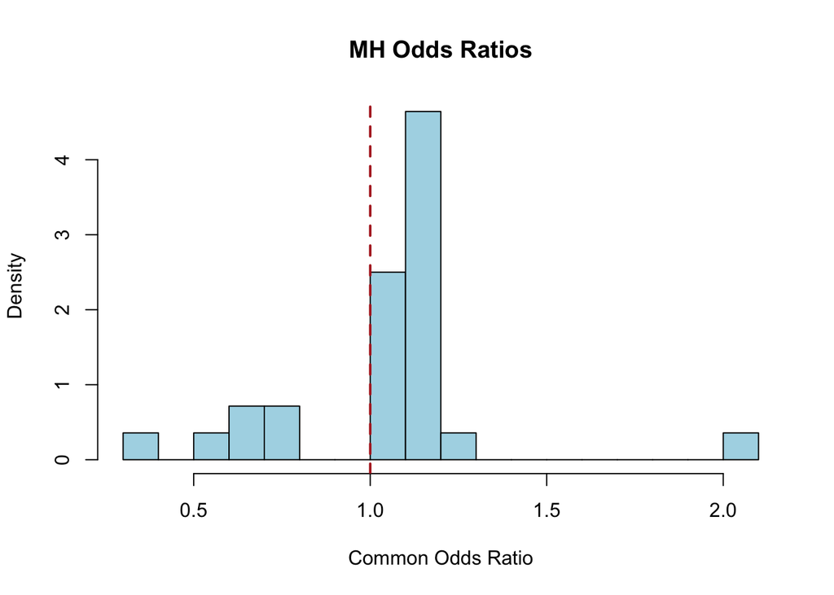

```r
mh_or <- rep(0, 28)
mh_pval <- rep(0, 28)

for (i in 1:28) {
  temp <- mantelhaen.test(DIF.data[, i], y = DIF.data$Male, z = diftot,
                          alternative = "two.sided", conf.level = 0.95)
  mh_or[i] <- temp$estimate
  mh_pval[i] <- temp$p.value
}

# Visualize odds ratios
hist(mh_or, breaks = 15, main = "MH Odds Ratios", xlab = "Common Odds Ratio",
     col = "lightblue", freq = FALSE)
abline(v = 1, col = "firebrick", lwd = 2, lty = 2)
```

## 4.3 2c: ETS delta classification

Transform the MH odds ratios into ETS delta statistics. Classify each item as Level A, B, or C.

```r
delta <- -2.35 * log(mh_or)

# Classification
level <- ifelse(abs(delta) >= 1.5, "C",
          ifelse(abs(delta) > 1, "B", "A"))

# Direction: positive delta = favors females, negative delta = favors males
direction <- ifelse(delta > 0, "Favors Females", "Favors Males")

# Summary table
mh_results <- data.frame(
  Item = 1:28,
  OR = round(mh_or, 3),
  Delta = round(delta, 3),
  p_value = round(mh_pval, 4),
  Significant = ifelse(mh_pval < 0.05, "Yes", "No"),
  Direction = direction,
  Level = level
)

mh_results |>
  kable("html") |>
  kable_styling(full_width = FALSE)
```

| Item | OR | Delta | p_value | Significant | Direction | Level |
| --- | --- | --- | --- | --- | --- | --- |
| 1 | 1.139 | -0.307 | 0.2129 | No | Favors Males | A |
| 2 | 1.119 | -0.265 | 0.3276 | No | Favors Males | A |
| 3 | 1.199 | -0.426 | 0.1205 | No | Favors Males | A |
| 4 | 1.157 | -0.342 | 0.1615 | No | Favors Males | A |
| 5 | 0.788 | 0.560 | 0.0115 | Yes | Favors Females | A |
| 6 | 1.156 | -0.341 | 0.2015 | No | Favors Males | A |
| 7 | 1.061 | -0.139 | 0.6282 | No | Favors Males | A |
| 8 | 1.088 | -0.199 | 0.3972 | No | Favors Males | A |
| 9 | 1.193 | -0.414 | 0.2666 | No | Favors Males | A |
| 10 | 0.547 | 1.418 | 0.0000 | Yes | Favors Females | B |
| 11 | 1.216 | -0.459 | 0.2903 | No | Favors Males | A |
| 12 | 1.131 | -0.289 | 0.2409 | No | Favors Males | A |
| 13 | 1.115 | -0.257 | 0.3477 | No | Favors Males | A |
| 14 | 1.104 | -0.233 | 0.3634 | No | Favors Males | A |
| 15 | 1.016 | -0.037 | 0.9214 | No | Favors Males | A |
| 16 | 1.092 | -0.208 | 0.4123 | No | Favors Males | A |
| 17 | 1.109 | -0.243 | 0.3579 | No | Favors Males | A |
| 18 | 1.065 | -0.147 | 0.5692 | No | Favors Males | A |
| 19 | 1.117 | -0.260 | 0.3096 | No | Favors Males | A |
| 20 | 0.386 | 2.237 | 0.0000 | Yes | Favors Females | C |
| 21 | 1.127 | -0.281 | 0.3113 | No | Favors Males | A |
| 22 | 1.133 | -0.293 | 0.2590 | No | Favors Males | A |
| 23 | 1.050 | -0.115 | 0.6549 | No | Favors Males | A |
| 24 | 1.091 | -0.204 | 0.4955 | No | Favors Males | A |
| 25 | 0.727 | 0.749 | 0.0028 | Yes | Favors Females | A |
| 26 | 0.602 | 1.193 | 0.0000 | Yes | Favors Females | B |
| 27 | 0.617 | 1.135 | 0.0000 | Yes | Favors Females | B |
| 28 | 2.091 | -1.734 | 0.0000 | Yes | Favors Males | C |

```r
# Level counts
cat("Level A (negligible):", sum(level == "A"), "\n")
```

```
## Level A (negligible): 23
```

```r
cat("Level B (moderate):  ", sum(level == "B"), "\n")
```

```
## Level B (moderate):   3
```

```r
cat("Level C (large):     ", sum(level == "C"), "\n")
```

```
## Level C (large):      2
```

**Question 2**: Based on the MH analysis, which items would you flag for DIF? For each flagged item, indicate: (a) the direction of DIF (which group is disadvantaged), (b) whether the result is statistically significant, and (c) the ETS classification level.

> Seven items are statistically significant (p < .05) and show notable DIF:
> - **Item 5**: OR = 0.79, delta = +0.56, Level A, favors females. Significant but small effect.
> - **Item 10**: OR = 0.55, delta = +1.42, Level B, favors females. Moderate DIF—males are disadvantaged.
> - **Item 20**: OR = 0.39, delta = +2.24, **Level C**, favors females. The largest DIF effect in the dataset. Males are substantially disadvantaged on this item.
> - **Item 25**: OR = 0.73, delta = +0.75, Level A, favors females. Significant but small.
> - **Item 26**: OR = 0.60, delta = +1.19, Level B, favors females. Moderate DIF.
> - **Item 27**: OR = 0.62, delta = +1.14, Level B, favors females. Moderate DIF.
> - **Item 28**: OR = 2.09, delta = -1.73, **Level C**, favors males. Large DIF in the opposite direction from the other flagged items.

> Two items reach Level C (items 20 and 28), and three reach Level B (items 10, 26, 27). Notably, 6 of the 7 flagged items favor females, while only item 28 favors males. This asymmetry has important implications for test-level validity (see Exercise 5).

> **Important**: MH did **not** flag item 15. As we will see, `lordif` does flag this item—it has non-uniform DIF that MH is not well-suited to detect.

# 5 Exercise 3: DIF Analysis Using lordif

## 5.1 3a: Run lordif

Reload the data (without the factor conversion) and run the `lordif` algorithm with the $\chi^2$ criterion at $\alpha$ = 0.01.

```r
library(lordif)

# Reload data as numeric
DIF.data <- read.csv("DIF.data2.csv")

# Run lordif
dif_result <- lordif(DIF.data[, 1:28], DIF.data[, 29],
                     criterion = "Chisqr", alpha = 0.01, minCell = 5)
```

```
##  (mirt) | Iteration: 1, 8 items flagged for DIF (5,10,15,20,25,26,27,28)
##  (mirt) | Iteration: 2, 8 items flagged for DIF (5,10,15,20,25,26,27,28)
```

## 5.2 3b: Examine and interpret results

Use `print()` to examine the flagged items and their associated statistics.

```r
print(dif_result)
```

```
## Call:
## lordif(resp.data = DIF.data[, 1:28], group = DIF.data[, 29],
##     criterion = "Chisqr", alpha = 0.01, minCell = 5)
##
##   Number of DIF groups: 2
##
##   Number of items flagged for DIF: 8 of 28
##
##   Items flagged: 5, 10, 15, 20, 25, 26, 27, 28
##
##   Number of iterations for purification: 2 of 10
##
##   Detection criterion: Chisqr
##
##   Threshold: alpha = 0.01
##
##    item ncat  chi12  chi13  chi23
## 1     1    2 0.7697 0.9564 0.9534
## 2     2    2 0.9457 0.9490 0.7517
## 3     3    2 0.8274 0.9191 0.7277
## 4     4    2 0.7598 0.9338 0.8348
## 5     5    2 0.0021 0.0084 0.7681
## 6     6    2 0.8429 0.8934 0.6661
## 7     7    2 0.9061 0.9911 0.9493
## 8     8    2 0.9573 0.9929 0.9149
## 9     9    2 0.7947 0.9514 0.8583
## 10   10    2 0.0000 0.0000 0.4154
## 11   11    2 0.8393 0.9774 0.9464
## 12   12    2 0.8413 0.8110 0.5382
## 13   13    2 0.7349 0.9385 0.9115
## 14   14    2 0.8505 0.9205 0.7183
## 15   15    2 0.3650 0.0000 0.0000
## 16   16    2 0.9337 0.9965 0.9913
## 17   17    2 0.9664 0.8318 0.5449
## 18   18    2 0.6703 0.8878 0.8116
## 19   19    2 0.9467 0.9978 0.9985
## 20   20    2 0.0000 0.0000 0.0314
## 21   21    2 0.9420 0.9973 0.9905
## 22   22    2 0.9839 0.8685 0.5957
## 23   23    2 0.7744 0.7864 0.5279
## 24   24    2 0.7736 0.9513 0.8961
## 25   25    2 0.0000 0.0002 0.6962
## 26   26    2 0.0000 0.0000 0.9283
## 27   27    2 0.0000 0.0000 0.3846
## 28   28    2 0.0000 0.0000 0.0180
```

**Question 3a**: Which items were flagged by `lordif`? How many iterations did the algorithm require?

> `lordif` flagged **8 items**: 5, 10, 15, 20, 25, 26, 27, and 28. The algorithm converged in **2 iterations**—the same 8 items were flagged in both iterations, so the purification process stabilized immediately.

## 5.3 3c: Diagnostic plots

Generate the diagnostic plots and examine them carefully.

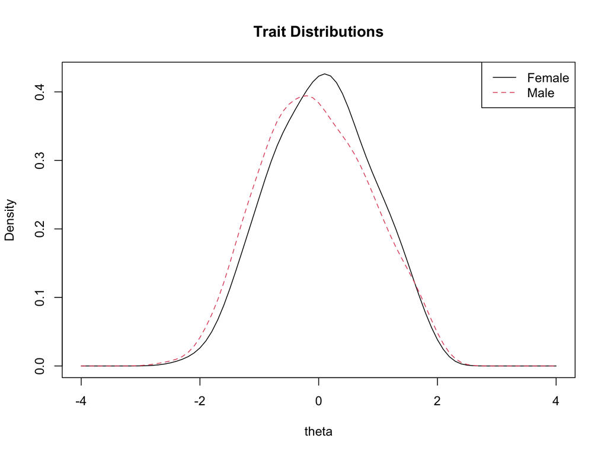

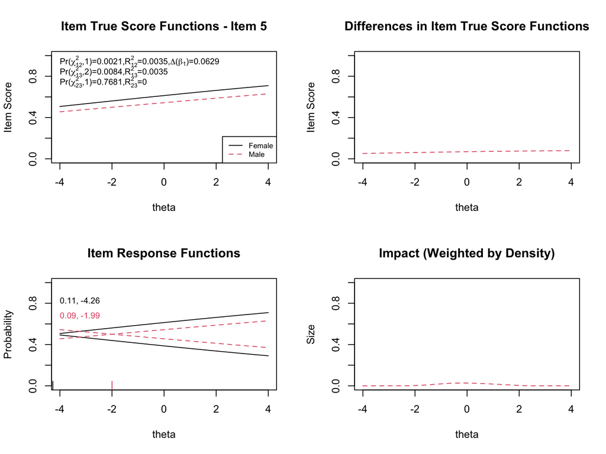

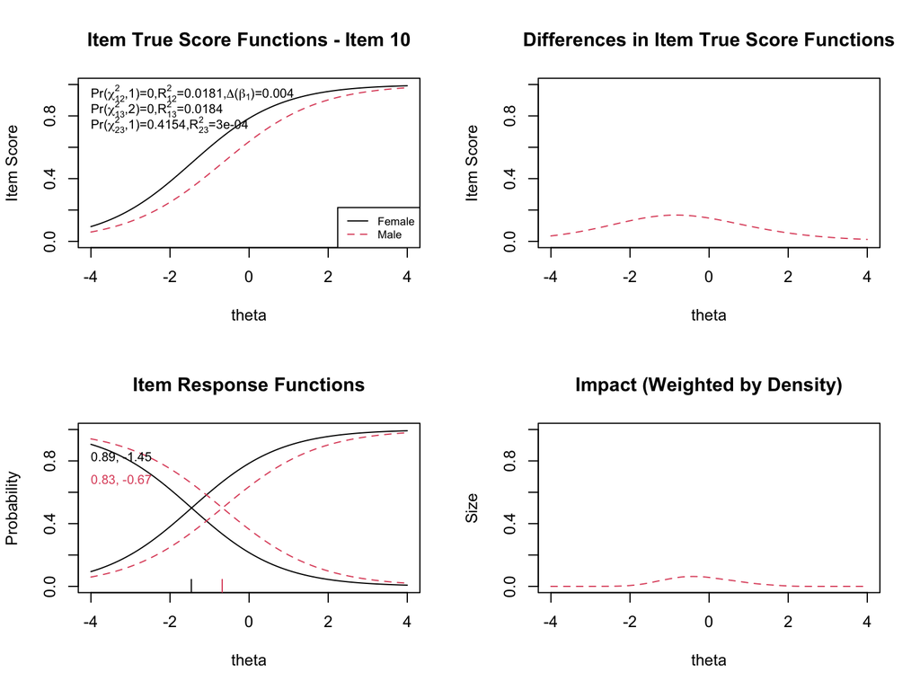

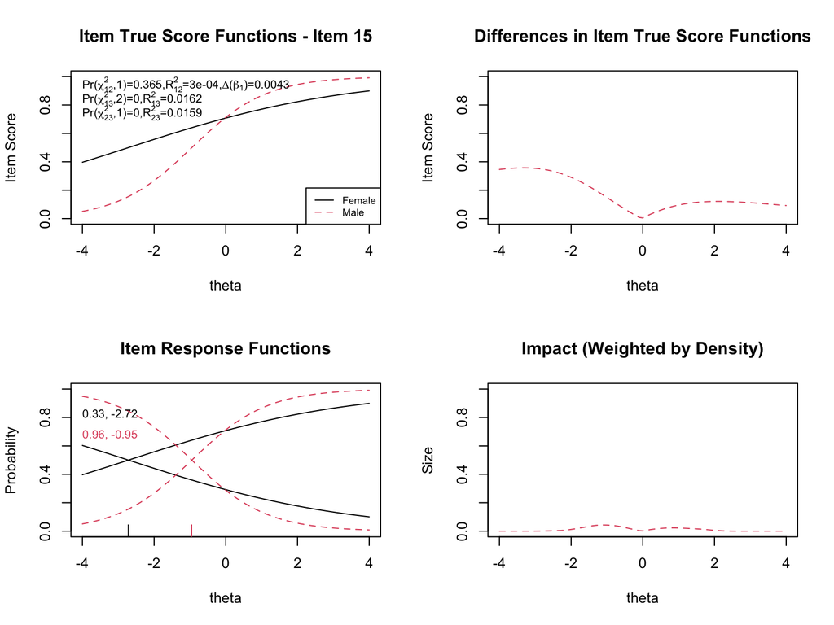

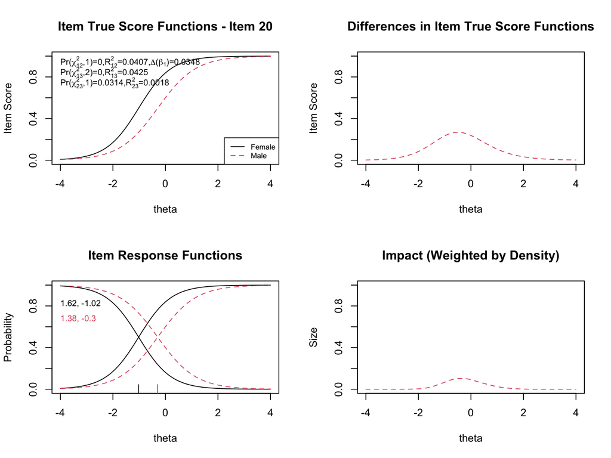

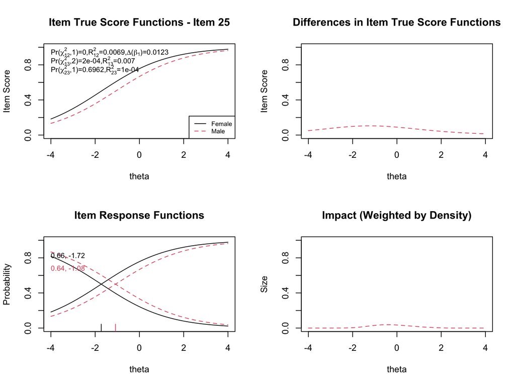

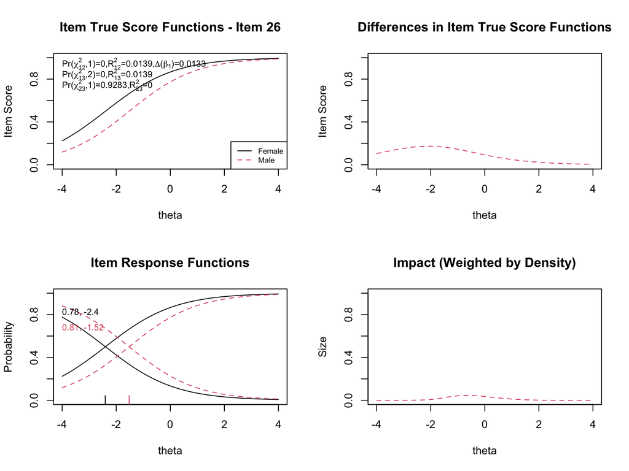

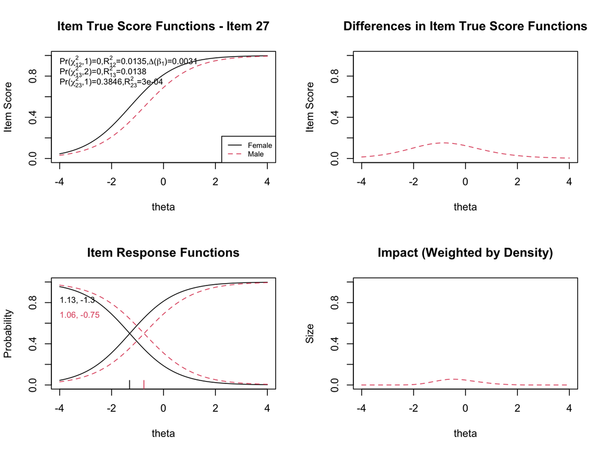

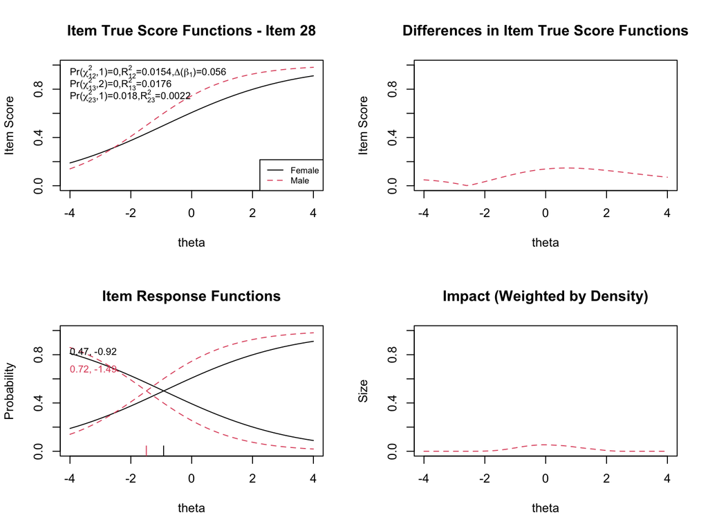

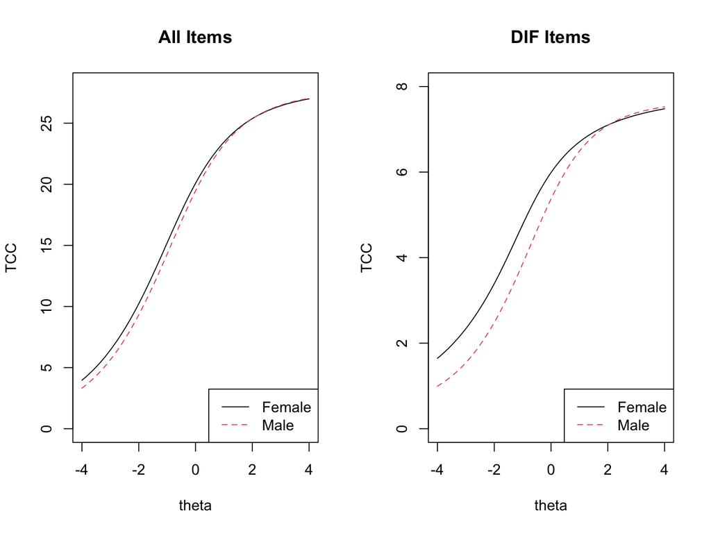

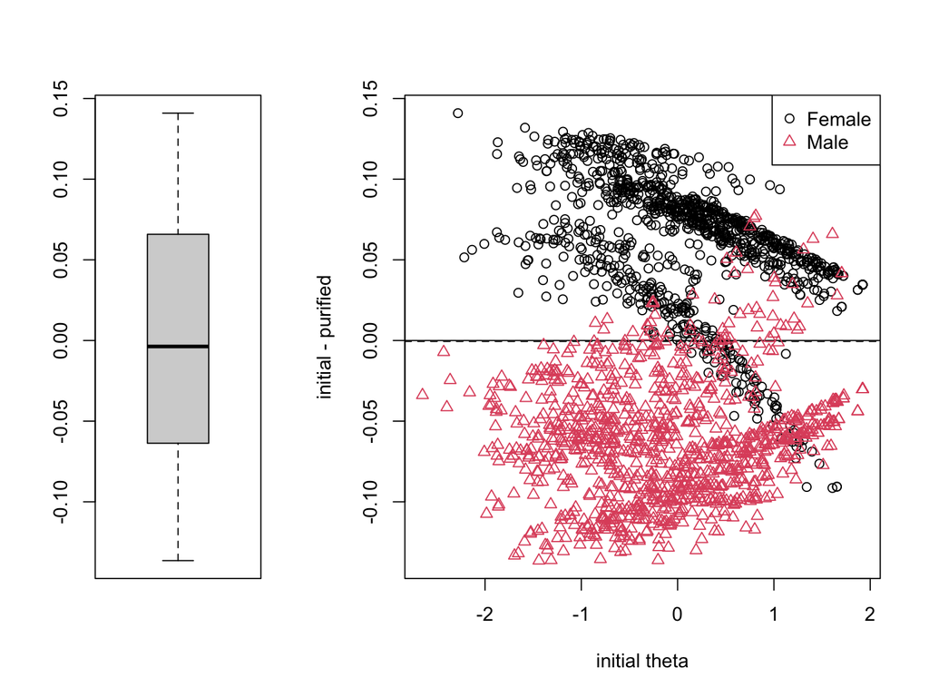

```r
plot(dif_result, labels = c("Female", "Male"), cex = 0.7)
```

It also helps to pull a few numerical summaries directly out of the `lordif` object. The initial trait estimates (ignoring DIF) are in `dif_result$calib$theta`; the purified trait estimates (accounting for DIF) are in `dif_result$calib.sparse$theta`. Group-specific item parameters for the flagged items are in `dif_result$ipar.sparse`.

```r
theta_init <- dif_result$calib$theta
theta_pur  <- dif_result$calib.sparse$theta
se_pur     <- dif_result$calib.sparse$SE
grp        <- DIF.data[, 29]

m_init_F <- mean(theta_init[grp == 0]); m_init_M <- mean(theta_init[grp == 1])
m_pur_F  <- mean(theta_pur[grp == 0]);  m_pur_M  <- mean(theta_pur[grp == 1])

cat("Initial theta  (no DIF adjustment):  F =", round(m_init_F, 3),
    " M =", round(m_init_M, 3),
    " M - F =", round(m_init_M - m_init_F, 3), "\n")
```

```
## Initial theta  (no DIF adjustment):  F = 0.11  M = -0.111  M - F = -0.221
```

```r
cat("Purified theta (DIF adjusted):       F =", round(m_pur_F, 3),
    " M =", round(m_pur_M, 3),
    " M - F =", round(m_pur_M - m_pur_F, 3), "\n")
```

```
## Purified theta (DIF adjusted):       F = 0.05  M = -0.049  M - F = -0.099
```

```r
cat("(The initial single-group calibration anchors the theta metric to\n")
```

```
## (The initial single-group calibration anchors the theta metric to
```

```r
cat(" population mean 0 and SD 1, so these mean differences are already\n")
```

```
##  population mean 0 and SD 1, so these mean differences are already
```

```r
cat(" in population-SD units.)\n\n")
```

```
##  in population-SD units.)
```

```r
shift <- theta_pur - theta_init
cat("Shift (purified - initial)\n")
```

```
## Shift (purified - initial)
```

```r
cat("  Mean for F:", round(mean(shift[grp == 0]), 3),
    "  Mean for M:", round(mean(shift[grp == 1]), 3), "\n")
```

```
##   Mean for F: -0.061   Mean for M: 0.062
```

```r
cat("  |shift| quantiles (50/75/95%):",
    round(quantile(abs(shift), c(0.5, 0.75, 0.95)), 3), "\n")
```

```
##   |shift| quantiles (50/75/95%): 0.065 0.088 0.117
```

```r
cat("  Max |shift|:", round(max(abs(shift)), 3), "logits\n")
```

```
##   Max |shift|: 0.141 logits
```

```r
cat("  Mean CSEM (purified theta):", round(mean(se_pur), 3), "logits\n")
```

```
##   Mean CSEM (purified theta): 0.474 logits
```

**Question 3b**: For each flagged item, describe the nature of the DIF: Is it uniform or non-uniform? Which group is advantaged? How large is the effect?

**Question 3c**: Examine the test-level impact plots (TCCs). Does DIF appear to amplify or cancel at the test level?

**Question 3d**: Examine the individual-level impact plot. What is the typical magnitude of score change when DIF is accounted for? Is this large relative to the standard error of measurement?

> The individual-level plot shows a systematic pattern: males are pulled upward and females downward when the DIF items are re-parameterized group-by-group. Numerically, the mean shift is about $+0.06$ logits for males and $-0.06$ logits for females; the median absolute shift is 0.065 logits, the 75th percentile is 0.088, the 95th percentile is 0.117, and the largest single shift is about 0.14 logits. The relevant denominator at the individual level is the **conditional standard error of measurement (CSEM)**, which reflects the measurement uncertainty each individual estimate already carries; here the mean CSEM of the purified $\hat{\theta}$ is about 0.47 logits. By the CSEM benchmark, any one examinee’s score moves by well under a CSEM, so the DIF-induced shift is unlikely to flip an individual’s classification.

> But this is exactly the scenario in which the two benchmarks disagree and the disagreement matters. The CSEM benchmark suggests individual-level effects are small, and it is correct about that. At the same time, the shifts are **systematic by group**—females move down and males move up in almost every case—and that systematic directional component is precisely what shows up at the group level as a shrinkage of the mean gap from about $-0.22$ to about $-0.10$ SD units. In other words, individual scores move only a little, but they move in the *same direction* within each group, and those small shifts accumulate in group-mean comparisons. The population-SD benchmark is more sensitive to this kind of directional bias than the CSEM is, which is why it is the right benchmark for evaluating the impact of DIF on between-group inferences.

# 6 Exercise 4: Compare Methods

**Question 4a**: Create a table or list comparing which items were flagged by MH versus `lordif`. Which items were flagged by both methods? Which were flagged by only one?

```r
mh_flagged <- which(mh_pval < 0.05 & abs(delta) > 0.5)
lordif_flagged <- which(dif_result$flag)

cat("MH flagged items (p < .05 and |delta| > 0.5):", sort(mh_flagged), "\n")
```

```
## MH flagged items (p < .05 and |delta| > 0.5): 5 10 20 25 26 27 28
```

```r
cat("lordif flagged items:                         ", sort(lordif_flagged), "\n")
```

```
## lordif flagged items:                          5 10 15 20 25 26 27 28
```

```r
both <- intersect(mh_flagged, lordif_flagged)
mh_only <- setdiff(mh_flagged, lordif_flagged)
lordif_only <- setdiff(lordif_flagged, mh_flagged)

cat("\nFlagged by both:    ", if (length(both) > 0) both else "none", "\n")
```

```
##
## Flagged by both:     5 10 20 25 26 27 28
```

```r
cat("MH only:            ", if (length(mh_only) > 0) mh_only else "none", "\n")
```

```
## MH only:             none
```

```r
cat("lordif only:        ", if (length(lordif_only) > 0) lordif_only else "none", "\n")
```

```
## lordif only:         15
```

> The two methods agree on 7 items (5, 10, 20, 25, 26, 27, 28) but **disagree on item 15**:
> - **Flagged by both**: Items 5, 10, 20, 25, 26, 27, 28
> - **MH only**: none
> - **lordif only**: Item 15

> The disagreement on item 15 is the most instructive result of this exercise.

**Question 4b**: Why might the two methods disagree about certain items? Consider differences in the matching criterion, sensitivity to uniform vs. non-uniform DIF, and the iterative purification process.

> The disagreement on item 15 illustrates a key limitation of MH. Item 15 has **non-uniform DIF**: the male and female ICCs cross because males have a substantially higher discrimination parameter. At low ability levels, the item favors females; at high ability levels, it favors males. MH computes a single common odds ratio across all ability strata. When the DIF reverses direction across the ability range, these opposing effects cancel out in the MH statistic, producing a near-zero delta and a non-significant p-value. MH effectively “averages away” the non-uniform DIF.

> `lordif` detects item 15 because its logistic regression framework explicitly tests for non-uniform DIF by including a group $\times$ ability interaction term. The likelihood ratio test comparing Model 2 (uniform DIF) to Model 3 (uniform + non-uniform) captures the crossing ICC pattern.

> Additional reasons the methods can disagree:
> - **Matching criterion**: MH uses observed total score (contaminated by DIF items); `lordif` uses purified IRT-based $\hat{\theta}$.
> - **Iterative purification**: `lordif` refines the matching criterion across iterations, potentially improving sensitivity. MH uses a single unpurified total score.
> - **Statistical framework**: The chi-square tests in MH and `lordif` have different degrees of freedom and power characteristics.

**Question 4c**: Based on your full analysis, which items would you recommend for further content review by subject matter experts? Justify your recommendation.

> I would recommend **all 8 flagged items** for content review, with priority given to the following:
> 1. **Item 20** (highest priority): Level C DIF favoring females, the largest effect in the dataset.
> 2. **Item 28** (high priority): Level C DIF favoring males. As the only item strongly favoring males, it stands out and warrants close scrutiny.
> 3. **Item 15** (high priority): Non-uniform DIF that was missed by MH. The crossing ICC pattern is unusual and suggests a complex interaction between gender and ability on this item.
> 4. **Items 10, 26, 27** (moderate priority): Level B DIF, all favoring females.
> 5. **Items 5, 25** (lower priority): Statistically significant but smaller effects (Level A).

> Content reviewers should look for common features among the 7 items favoring females. If these items share content themes, formats, or language features, the pattern may point to a systematic source of construct-irrelevant variance. Item 28 should be examined separately to understand why it is the sole item favoring males.

# 7 Comparison to Ground Truth

Now that we have results from both methods, let’s compare them to the known generating parameters.

```r
# True DIF items and their properties
true_dif <- c(5, 10, 15, 20, 25, 26, 27, 28)
true_direction <- c("Favors Females", "Favors Females", "Favors Females",
                     "Favors Females", "Favors Females", "Favors Females",
                     "Favors Females", "Favors Males")
true_type <- c("Uniform", "Uniform", "Non-uniform",
               "Uniform", "Uniform", "Uniform",
               "Uniform", "Uniform")
true_magnitude <- c("1.2 logits", "1.1 logits", "1.0 logits",
                     "0.9 logits", "0.8 logits", "0.7 logits",
                     "0.6 logits", "1.0 logits")

# Detection results
mh_detected <- true_dif %in% mh_flagged
lordif_detected <- true_dif %in% lordif_flagged

# MH direction recovery (for detected items)
mh_dir <- ifelse(delta[true_dif] > 0, "Favors Females", "Favors Males")

comparison <- data.frame(
  Item = true_dif,
  True_Direction = true_direction,
  True_Type = true_type,
  Magnitude = true_magnitude,
  MH_Detected = ifelse(mh_detected, "Yes", "**No**"),
  MH_Direction = mh_dir,
  MH_Level = level[true_dif],
  lordif_Detected = ifelse(lordif_detected, "Yes", "No")
)

comparison |>
  kable("html",
        col.names = c("Item", "True Direction", "True DIF Type", "Magnitude",
                       "MH Detected?", "MH Direction", "MH Level",
                       "lordif Detected?")) |>
  kable_styling(full_width = FALSE)
```

| Item | True Direction | True DIF Type | Magnitude | MH Detected? | MH Direction | MH Level | lordif Detected? |
| --- | --- | --- | --- | --- | --- | --- | --- |
| 5 | Favors Females | Uniform | 1.2 logits | Yes | Favors Females | A | Yes |
| 10 | Favors Females | Uniform | 1.1 logits | Yes | Favors Females | B | Yes |
| 15 | Favors Females | Non-uniform | 1.0 logits | **No** | Favors Males | A | Yes |
| 20 | Favors Females | Uniform | 0.9 logits | Yes | Favors Females | C | Yes |
| 25 | Favors Females | Uniform | 0.8 logits | Yes | Favors Females | A | Yes |
| 26 | Favors Females | Uniform | 0.7 logits | Yes | Favors Females | B | Yes |
| 27 | Favors Females | Uniform | 0.6 logits | Yes | Favors Females | B | Yes |
| 28 | Favors Males | Uniform | 1.0 logits | Yes | Favors Males | C | Yes |

```r
# False positives
mh_false_pos <- setdiff(mh_flagged, true_dif)
lordif_false_pos <- setdiff(lordif_flagged, true_dif)
cat("MH false positives:", if (length(mh_false_pos) > 0) mh_false_pos else "none", "\n")
```

```
## MH false positives: none
```

```r
cat("lordif false positives:", if (length(lordif_false_pos) > 0) lordif_false_pos else "none", "\n")
```

```
## lordif false positives: none
```

**Summary**: The two methods performed differently on this dataset, and the difference is instructive:

# 8 Exercise 5: Reflection

**Question 5**: Suppose you found strong evidence of DIF for several items, all favoring the same group. What are the implications for the validity of total score comparisons between groups? How would you advise a test developer who received these results?

> This dataset illustrates exactly this scenario: 7 of 8 DIF items favor females. The implications are serious:
> - **Test-level bias**: Because the DIF effects amplify rather than cancel, the total score is systematically biased. Females receive a score “bonus” of 1–2 points (on a 28-item test) that is not attributable to differences in the construct being measured. This means observed female-male score differences overstate the true ability gap.
> - **Validity threat**: The test fails to satisfy the requirement of **measurement invariance**—it does not function the same way for both groups. Any interpretation of group mean differences (e.g., for program evaluation, placement decisions, or policy) is compromised.
> - **Individual-level consequences**: If cut scores are used for classification (e.g., proficient vs. not proficient), some males near the cut may be misclassified as non-proficient when they would have been classified as proficient on a DIF-free test.

> I would advise the test developer to:
> - **Prioritize content review** for items 20, 28, and 15 (the most extreme cases), then the Level B items.
> - **Investigate the source**: Do the DIF items share content features? If so, the DIF may reflect construct-irrelevant factors (e.g., reading load, cultural context) rather than true ability differences.
> - **Consider corrective action**: Remove or revise Level C items. For Level B items, revision is preferred over removal to maintain content coverage.
> - **Re-examine the scoring model**: If DIF items cannot be removed (e.g., for content validity reasons), consider adjusting the scoring model to account for DIF (e.g., using group-specific item parameters).
> - **Monitor in future administrations**: Flag these items for ongoing DIF analysis. If DIF persists after revision, the items may be fundamentally problematic for cross-group comparison.
> - **Be transparent**: Report the DIF findings in the technical documentation. Stakeholders who use score comparisons between groups need to understand the limitations.